# DEM 7223 - Event History Analysis - Discrete Time Hazard Model Part 1

- Show All Code
- Hide All Code
- View Source

Author

Affiliation

[Corey S. Sparks, PhD](https://coreysparks.github.io)

[The University of Texas at San Antonio](https://hcap.utsa.edu/demography)

Published

October 7, 2022

# Notes

## Person-Level vs. Person-Period

- In the continuous time hazards world, the person-level data is satisfactory, because it provides:
1. the duration time for each individual in the data, which tells how long the person was at risk
2. the censoring indicator which tells if the person actually experienced the event of interest
3. the covariates that describe the effects of the person’s characteristics on their “risk score”
- This data format was sufficient when we considered the continuous time treatment of the hazard model given by the K-M estimator, parametric models and the Cox model.

### Person - period data

- In contrast, the person-period data represents a discrete-time representation of the duration data.
- In the person-period world, each observation contributes one “period” of risk for each time point they are at risk of experiencing the event
  - e.g. if we are talking about marital duration, and one couple experiences a divorce 2 years after marriage, if we measure “periods” as years, then this couple would contribute 2 “observations” to the data, because they were at risk the first year and experienced the event their second year.
- So each duration for each person, measured as time=Ti will have $t_{ij}$ episodes in the new period-based data
- Each individual will exist in the data until they experience the event, or they are censored, and will contribute no more to the data after this point.
- This means that at each $t_{ij}$ there is a certain number of persons at risk of experiencing the event and a certain number that do; which is the definition of a hazard rate
- The biggest issue is getting the data into the appropriate format
- We have already done this with the piecewise-constant hazard model
- There we specified arbitrary breaks, now we specify more structured time periods

| ID | Period | Event |
| --- | --- | --- |
| 1 | 1 | 0 |
| 1 | 2 | 0 |
| 1 | 3 | 0 |
| 1 | 4 | 0 |
| 1 | 5 | 1 |
| 2 | 1 | 0 |
| 2 | 2 | 1 |
| 3 | 1 | 0 |
| 3 | 2 | 0 |
| 3 | 3 | 0 |
| 3 | 4 | 0 |
| 3 | 5 | 0 |
| 3 | 6 | 0 |
| 3 | 7 | 0 |
| 3 | 8 | 0 |
| 3 | 9 | 0 |
| 4 | 1 | 0 |
| 4 | 2 | 0 |
| 4 | 3 | 0 |
| 4 | 4 | 0 |
| 4 | 5 | 0 |
| 4 | 6 | 0 |

| Period | haz |
| --- | --- |
| 1 | 0.0000000 |
| 2 | 0.2500000 |
| 3 | 0.0000000 |
| 4 | 0.0000000 |
| 5 | 0.3333333 |
| 6 | 0.0000000 |
| 7 | 0.0000000 |
| 8 | 0.0000000 |
| 9 | 0.0000000 |

## Constructing Hazards for each period

- In the person-period world, we can construct the hazard of an event occurring at a specific time just as in the continuous time world.
- This is still the conditional failure probability at each time point, and is still calculated by dividing:

$$h(t) = \frac{\text{y failures}} {\text{n at risk}}$$

- This is very similar to how life-tables are constructed, except in this perspective we allow for individual covariate effects on the hazard.

### Expressing the hazards in alternative forms:

- There are several ways to present the discrete time hazard rate
  - Probability scale (bound between 0 – 1)
  - These are tough bounds to work within
- Odds scale (bound 0 – inf)
  - odds= $\frac{h(t)} {1-h(t)}$, expresses the probability of an event occurring to the probability that it did not occur
  - Bad thing is that it includes 0 as a possible value
- log-odds (or logit) $ln \left ( \frac{h(t)} {1-h(t)} \right )$, which is unbounded
  - log scale allows for easier comparison of hazards over time, makes big differences smaller, and small differences bigger and homogenizes variability

## Modeling the hazard for each period

- This is typically done via logistic regression!
  - e.g.

$$logit(h(t))=[\alpha_1 D_1 + \alpha_2 D_2 +...+\alpha_t D_T]+x'\beta$$
* Where the $D$’s represent the distinct risk periods, the $\alpha$’s represent the shape of the log-odds for the hazard at each time, and the $\beta$’s represent the effects of covariates on the hazard.

- This formulation is called the *general form model* because it allows the shape of the hazard function to vary at each time point, as defined by the $\alpha$’s!
- This allows great flexibility in modeling the changing nature of risk
- It is constrained (for the time-being) on the assumption that the covariates are not time-dependent, and their effect is the same in each risk period
- Each of the $\alpha$’s represents the value of the logit hazard (log-odds) of an event occurring at that particular time point for individuals in the “baseline group” → no covariate effect
- The $\beta$’s, or slope parameters, assess the effect of a 1 unit difference in a covariate on the risk of the event occurring.
- Similar to what we saw in the proportional hazards model, the discrete time model has the following interpretation
- When the covariates are not time-dependent
- if $x_1$ is our only covariate, the log-odds can be written:

$$\text{if x=1}: logit(h(t))=[\alpha_1 D_1 + \alpha_2 D_2 +...+\alpha_t D_T]+[ \beta_1 x_1]$$

$$\text{if x=0}: logit(h(t))=[\alpha_1 D_1 + \alpha_2 D_2 +...+\alpha_t D_T]$$

- So when x=1 the entire hazard is increased (or decreased) by the constant, $\beta$.
- This effect is assumed to be constant at all time points and can be compared to the proportional hazards assumption
- When x=0 this is called the *baseline logit hazard function*
- The parameters $\alpha_1 D_1 + \alpha D_2 +...+\alpha_t D_t$ act as t distinct intercept parameters, describing the baseline risk (on a log odds scale) at each risk period of time, T.

### Expressions for the hazard

- Sometimes we want to express the hazard in a different scale (instead of the logit scale, we want the probability scale)
- Singer & Willett p 376 give transformations (or inversions) for going between the scales
  - These are the same as the transformations of the probability into the log-odds as in logistic regression
  - For instance if we want to express the entire regression in the probability scale we do:

  $$h(t_{ij}) = \frac{1}{1+exp -(\alpha_1 D_1 + \alpha_2 D_2 +...+\alpha_t D_T+ x'\beta)}$$

### Interpreting the coefficients

- The $\alpha$’s represent the shape of the hazard at each time period. If they are approximately equal, then the hazard is flat over time, if they decline over time, so does the hazard and vice versa.
- We can also see nonlinear changes in the hazard an important consideration in interpreting the $\alpha$’s is the identification of the baseline group, this is the group for which all x’s are 0, so you may need to standardize any continuous covariates.
- The $\beta$’s represent the effect of the covariates.
- For a dichotomous predictor (or indeed a continuous predictor that is z scored), these indicate the shift in the log-odds for an individual with x=1 relative to x=0
- if $\beta >0$, the odds ratio is >1, This represents an increase in the odds of experiencing the event, $\beta<0$, and the odds ratio <1, represents a decrease in the odds of experiencing the event
- If we use dummy variable coding for a factor variable, remember the interpretation in always done in reference to the category you leave out

# Data Examples

This example will illustrate how to fit the discrete time hazard model to longitudinal and continuous duration data (i.e. person-level data).

The first example will use as its outcome variable, the event of a child dying before age 5. The data for this example come from the data [Demographic and Health Survey for 2016](http://www.dhsprogram.com/data/model-datasets.cfm) children’s recode file. This file contains information for all births in the last 5 years prior to the survey.

The longitudinal data example uses data from the [ECLS-K](http://nces.ed.gov/ecls/kinderdatainformation.asp). Specifically, we will examine the transition into poverty between kindergarten and 8th grade.

# Using Longitudinal Data

As in the other examples, I illustrate fitting these models to data that are longitudinal, instead of person-duration. In this example, we will examine how to fit the Cox model to a longitudinally collected data set.

```r
#Load required libraries
library(foreign)
library(survival)
library(car)
library(survey)
library(eha)
library(tidyverse)
options(survey.lonely.psu = "adjust")
```

```r
eclskk5<-readRDS("C:/Users/ozd504/OneDrive - University of Texas at San Antonio/classes/dem7223/dem7223_22//data/eclskk5.rds")
names(eclskk5)<-tolower(names(eclskk5))
#get out only the variables I'm going to use for this example
myvars<-c( "childid","x_chsex_r", "x_raceth_r", "x1kage_r","x4age",
           "x5age", "x6age", "x7age", "x2povty","x4povty_i", "x6povty_i",
           "x8povty_i","x12par1ed_i", "s2_id","w6c6p_6psu",
           "w6c6p_6str", "w6c6p_20")
eclskk5<-eclskk5[,myvars]


# time varying variables
eclskk5$age_1<-ifelse(eclskk5$x1kage_r==-9, NA, eclskk5$x1kage_r/12)
eclskk5$age_2<-ifelse(eclskk5$x4age==-9, NA, eclskk5$x4age/12)
#for the later waves, the NCES group the ages into ranges of months,
#so 1= <105 months, 2=105 to 108 months.
#So, I fix the age at the midpoint of the interval they give,
#and make it into years by dividing by 12

eclskk5$age_3<-ifelse(eclskk5$x5age==-9, NA, eclskk5$x5age/12)

eclskk5$pov_1<-ifelse(eclskk5$x2povty==1,1,0)
eclskk5$pov_2<-ifelse(eclskk5$x4povty_i==1,1,0)
eclskk5$pov_3<-ifelse(eclskk5$x6povty_i==1,1,0)


#Time constant variables
#Recode race with white, non Hispanic as reference using dummy vars
eclskk5$race_rec<-Recode (eclskk5$x_raceth_r, recodes="1 = 'nhwhite';2='nhblack';3:4='hispanic';5='nhasian'; 6:8='other';-9=NA", as.factor = T)
eclskk5$male<-Recode(eclskk5$x_chsex_r, recodes="1=1; 2=0; -9=NA")
eclskk5$mlths<-Recode(eclskk5$x12par1ed_i, recodes = "1:2=1; 3:9=0; else = NA")
eclskk5$mgths<-Recode(eclskk5$x12par1ed_i, recodes = "1:3=0; 4:9=1; else =NA")
```

Now, I need to form the transition variable, this is my event variable, and in this case it will be 1 if a child enters poverty between the first wave of the data and the third grade wave, and 0 otherwise.

**NOTE** I need to remove any children who are already in poverty age wave 1, because they are not at risk of experiencing **this particular** transition. Again, this is called forming the *risk set*

```r
eclskk5<-eclskk5 %>% filter(is.na(pov_1)==F &
                  is.na(pov_2)==F &
                  is.na(pov_3)==F &
                  is.na(age_1)==F &
                  is.na(age_2)==F &
                  is.na(age_3)==F &
                    pov_1!=1)
```

Now we do the entire data set. To analyze data longitudinally, we need to reshape the data from the current “wide” format (repeated measures in columns) to a “long” format (repeated observations in rows). The `reshape()` function allows us to do this easily. It allows us to specify our repeated measures, time varying covariates as well as time-constant covariates.

```r
e.long1 <- eclskk5 %>%
  #rename(wt = w4c4p_40,strata= w4c4p_4str, psu = w4c4p_4psu)%>%
  select(childid,male, race_rec, mlths, mgths,   #time constant
        age_1, age_2, age_3, #t-varying variables
         pov_1, pov_2, pov_3,
        w6c6p_6psu, w6c6p_6str, w6c6p_20)%>%
   pivot_longer(cols = c(-childid, -male, -race_rec, -mlths, -mgths,-w6c6p_6psu, -w6c6p_6str, -w6c6p_20), #time constant variables go here
               names_to  = c(".value", "wave"), #make wave variable and put t-v vars into columns
               names_sep = "_") %>% #all t-v variables have _ between name and time, like age_1, age_2
  group_by(childid)%>%
  mutate(age_enter = round(age),
         age_exit = round(lead(age, 1, order_by=childid)))%>%
  mutate(nexpov = dplyr::lead(pov,n=1, order_by = childid))%>%
  mutate(povtran = ifelse(nexpov == 1 & pov == 0, 1, 0))%>%
  filter(is.na(age_exit)==F)%>%
  ungroup()%>%
  filter(complete.cases(age_enter, age_exit, povtran,
                        mlths, mgths, race_rec,w6c6p_6psu))
```

## Descriptive analysis of rates

Since we have a simple binary outcome, we can take the mean of it and arrive at our basic rates of occurrence of our event.

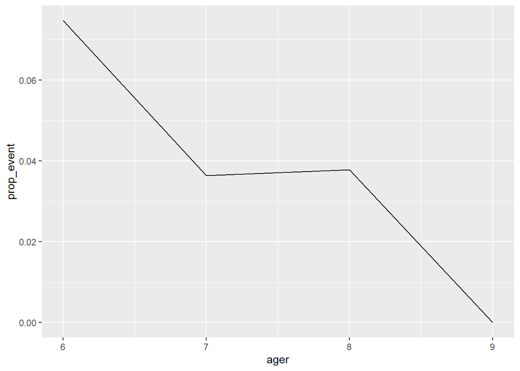

```r
e.long1%>%
  mutate(ager = round((age_enter+age_exit)/2) )%>%
  group_by(ager)%>%
  summarise(prop_event= mean(povtran, na.rm=T))%>%
  ggplot()+
  aes(x=ager, y= prop_event)+
  geom_line()
```

We can likewise do simple descriptive analysis of the outcome by characteristics of the respondents:

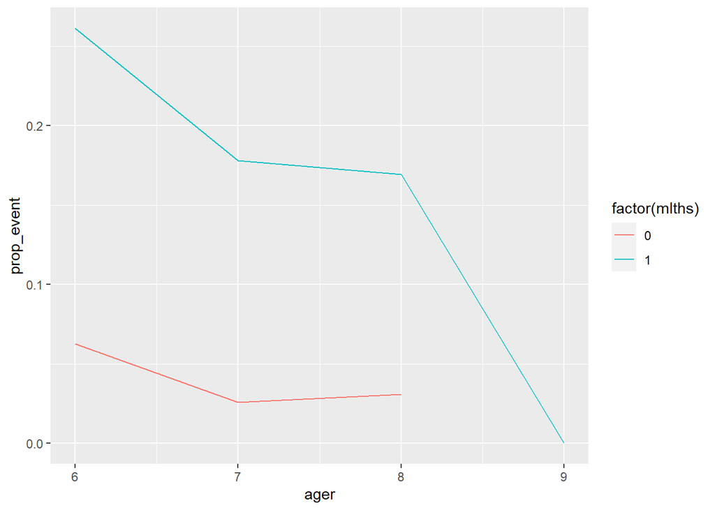

```r
e.long1%>%
  mutate(ager = round((age_enter+age_exit)/2) )%>%
  group_by(ager, mlths)%>%
  summarise(prop_event= mean(povtran, na.rm=T))%>%
  ggplot()+
  aes(x=ager, y= prop_event, color=factor(mlths) )+
  geom_line()
```

Now we fit the discrete time model using full survey design. In the ECLS-K, I use the longitudinal weight for waves 1-7, as well as the associated psu and strata id’s for the longitudinal data from these waves from the parents of the child, since no data from the child themselves are used in the outcome.

```r
options(survey.lonely.psu = "adjust")
e.long1<-e.long1%>%
  filter(complete.cases(w6c6p_6psu, race_rec, mlths))

des2<-svydesign(ids = ~w6c6p_6psu,
                strata = ~w6c6p_6str,
                weights=~w6c6p_20,
                data=e.long1,
                nest=T)
```

### Basic Discrete time model

Following the notation in the notes, we specify a generalized linear model for a binary outcome at each time period of risk. In this case, the binomial event is 0 if a child doesn’t transition into poverty between waves, and 1 if they do. This can be specified as a logistic regression model with a choice of link functions. We can use a logit specification for the hazard:

$\text{logit}(h(t))= \left [ \alpha_1 D_1 +\alpha_2 D_2 + \cdots \alpha_t D_t \right ]+ \sum_k \beta_k x_{k}$

$log(-log(1-h(t)))= \left [ \alpha_1 D_1 +\alpha_2 D_2 + \cdots \alpha_t D_t \right ]+ \sum_k \beta_k x_{k}$

while the choice of link function generally has no effect on predictions, the interpretation of the log-log link is the same as the proportional hazards model, instead of the odds ratio interpretation.

```r
#Fit the model
fitl1<-glm(povtran~as.factor(age_enter)+mlths - 1,
              e.long1, family=binomial)
summary(fitl1)
```

```
Call:
glm(formula = povtran ~ as.factor(age_enter) + mlths - 1, family = binomial,
    data = e.long1)

Deviance Residuals:
    Min       1Q   Median       3Q      Max
-0.8168  -0.3410  -0.2820  -0.2367   2.6793

Coefficients:
                      Estimate Std. Error z value Pr(>|z|)
as.factor(age_enter)5  -2.7287     0.1407 -19.390   <2e-16 ***
as.factor(age_enter)6  -2.8156     0.1172 -24.014   <2e-16 ***
as.factor(age_enter)7  -3.5612     0.1384 -25.725   <2e-16 ***
as.factor(age_enter)8  -3.2047     0.3009 -10.650   <2e-16 ***
as.factor(age_enter)9 -14.3683   324.7437  -0.044    0.965
mlths                   1.8022     0.1774  10.160   <2e-16 ***
---
Signif. codes:  0 '***' 0.001 '**' 0.01 '*' 0.05 '.' 0.1 ' ' 1

(Dispersion parameter for binomial family taken to be 1)

    Null deviance: 5661.6  on 4084  degrees of freedom
Residual deviance: 1611.7  on 4078  degrees of freedom
AIC: 1623.7

Number of Fisher Scoring iterations: 11
```

```r
round(100*(1/(1+exp(-coef(fitl1)))),2)
```

```
as.factor(age_enter)5 as.factor(age_enter)6 as.factor(age_enter)7
                 6.13                  5.65                  2.76
as.factor(age_enter)8 as.factor(age_enter)9                 mlths
                 3.90                  0.00                 85.84
```

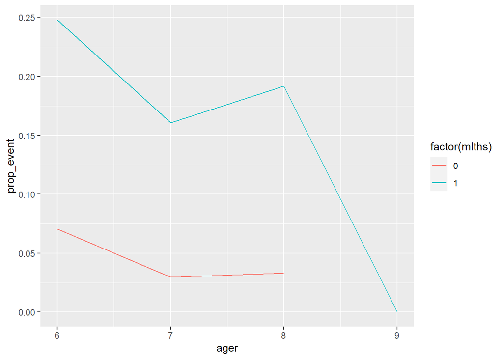

```r
library(questionr)


e.long1%>%
  mutate(ager = round((age_enter+age_exit)/2) )%>%
  group_by(ager, mlths)%>%
  summarise(prop_event= wtd.mean(povtran, na.rm=T, weights = w6c6p_20))%>%
  ggplot()+
  aes(x=ager, y= prop_event, color=factor(mlths) )+
  geom_line()
```

We can use the model to generate predicted probabilities for different types of people in our analysis:

```r
dat3<-expand.grid(age_enter =c(5,6,7,8),
                  mlths=c(0,1))
#unfortunately, expand.grid makes some unrealistic cases sometimes, get rid of those.

dat3$fitted<-as.numeric(predict(fitl1, dat3, type="response"))
knitr::kable(dat3)
```

| age_enter | mlths | fitted |
| --- | --- | --- |
| 5 | 0 | 0.0613031 |
| 6 | 0 | 0.0564875 |
| 7 | 0 | 0.0276207 |
| 8 | 0 | 0.0389910 |
| 5 | 1 | 0.2836522 |
| 6 | 1 | 0.2663259 |
| 7 | 1 | 0.1469238 |
| 8 | 1 | 0.1974346 |

# Continuous duration outcome - DHS data

### load the data

```r
library(haven)
#load the data
dat<-read_dta("../data/ZAIR71FL.DTA")
dat<-zap_labels(dat)
```

## Event - Second birth occurrence

In the DHS individual recode file, information on every live birth is collected using a retrospective birth history survey mechanism.

Since our outcome is time between first and second birth, we must select as our risk set, only women who have had a first birth.

The `bidx` variable indexes the birth history and if `bidx_01` is not missing, then the woman should be at risk of having a second birth (i.e. she has had a first birth, i.e. `bidx_01==1`).

I also select only non-twin births (`b0 == 0`).

The DHS provides the dates of when each child was born in Century Month Codes.

To get the interval for women who *actually had* a second birth, that is the difference between the CMC for the first birth `b3_01` and the second birth `b3_02`, but for women who had not had a second birth by the time of the interview, the censored time between births is the difference between `b3_01` and `v008`, the date of the interview.

We have 6124 women who are at risk of a second birth.

```r
sub<-dat %>%
  filter(bidx_01==1&b0_01==0)%>%
  transmute(CASEID=caseid,
                 int.cmc=v008,
                 fbir.cmc=b3_01,
                 sbir.cmc=b3_02,
                 marr.cmc=v509,
                 rural=v025,
                 educ=v106,
                 age = v012,
                 agec=cut(v012, breaks = seq(15,50,5), include.lowest=T),
                 partneredu=v701,
                 partnerage=v730,
                 weight=v005/1000000,
                 psu=v021,
                 strata=v022)%>%
  select(CASEID, int.cmc, fbir.cmc, sbir.cmc, marr.cmc, rural, educ, age, agec, partneredu, partnerage, weight, psu, strata)%>%
  mutate(agefb = (age - (int.cmc - fbir.cmc)/12))%>%
  mutate(secbi = ifelse(is.na(sbir.cmc)==T,
                   int.cmc - fbir.cmc,
                   fbir.cmc - sbir.cmc),
         b2event = ifelse(is.na(sbir.cmc)==T,0,1))

options(survey.lonely.psu = "adjust")
des<-svydesign(ids=~psu,
               strata=~strata,
               data=sub[sub$secbi>0,],
               weight=~weight )
```

### Create the person-period file

The distinction between the way we have been doing things and the discrete time model, is that we treat time discretely, versus continuously. This means that we transform the data from the case-duration data format to the person-period format. For this example, a natural choice would be year, since we have intervals of equal length (12 months each).

R provides a useful function called `survSplit()` in the `survival` library that will split a continuous duration into discrete periods.

```r
#make person period file
pp<-survSplit(Surv(secbi, b2event)~. ,
              data = sub[sub$secbi>0,],
              cut=seq(0,60, 12),
              episode="year_birth")

pp$year <- pp$year_birth-1
pp<-pp[order(pp$CASEID, pp$year_birth),]
knitr::kable(head(pp[, c("CASEID", "secbi", "b2event", "year", "educ", "agefb")], n=20))
```

| CASEID | secbi | b2event | year | educ | agefb |
| --- | --- | --- | --- | --- | --- |
| 1 13 2 | 12 | 0 | 1 | 1 | 24.66667 |
| 1 13 2 | 24 | 0 | 2 | 1 | 24.66667 |
| 1 13 2 | 36 | 0 | 3 | 1 | 24.66667 |
| 1 13 2 | 48 | 0 | 4 | 1 | 24.66667 |
| 1 13 2 | 60 | 0 | 5 | 1 | 24.66667 |
| 1 13 2 | 196 | 0 | 6 | 1 | 24.66667 |
| 1 36 2 | 12 | 0 | 1 | 2 | 22.75000 |
| 1 36 2 | 24 | 0 | 2 | 2 | 22.75000 |
| 1 36 2 | 36 | 0 | 3 | 2 | 22.75000 |
| 1 36 2 | 48 | 0 | 4 | 2 | 22.75000 |
| 1 36 2 | 51 | 0 | 5 | 2 | 22.75000 |
| 1 93 2 | 12 | 0 | 1 | 2 | 18.33333 |
| 1 93 2 | 24 | 0 | 2 | 2 | 18.33333 |
| 1 93 2 | 36 | 0 | 3 | 2 | 18.33333 |
| 1 93 2 | 44 | 0 | 4 | 2 | 18.33333 |
| 2 4 3 | 12 | 0 | 1 | 1 | 28.75000 |
| 2 4 3 | 24 | 0 | 2 | 1 | 28.75000 |
| 2 4 3 | 36 | 0 | 3 | 1 | 28.75000 |
| 2 4 3 | 48 | 0 | 4 | 1 | 28.75000 |
| 2 4 3 | 60 | 0 | 5 | 1 | 28.75000 |

## Descriptive analysis

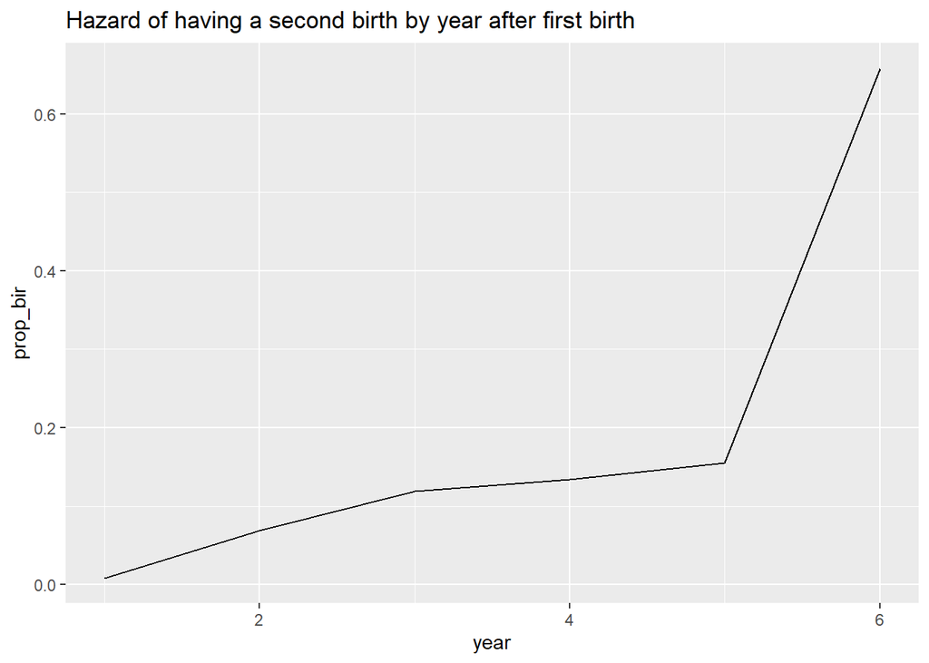

```r
pp%>%
  group_by(year)%>%
  summarise(prop_bir=mean(b2event, na.rm=T))%>%
  ggplot(aes(x=year, y=prop_bir))+
  geom_line()+
  ggtitle(label = "Hazard of having a second birth by year after first birth")
```

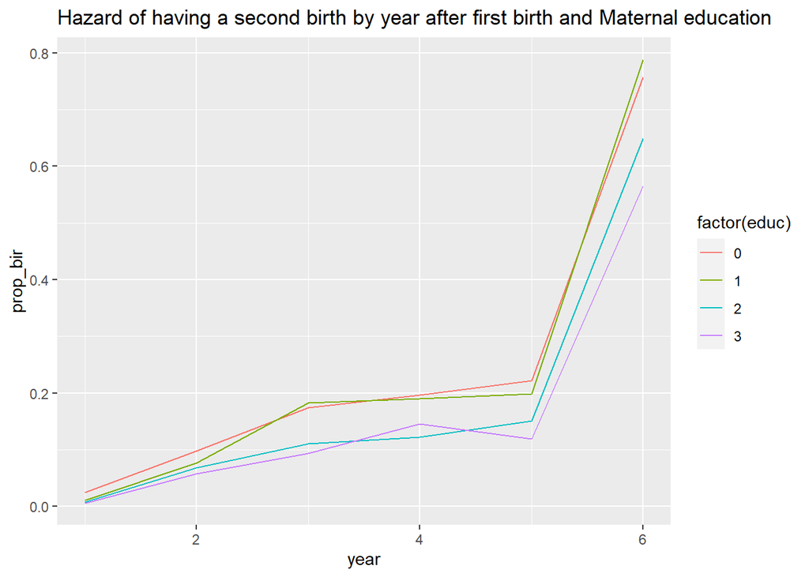

```r
pp%>%
  group_by(year, educ)%>%
  summarise(prop_bir=mean(b2event, na.rm=T))%>%
  ggplot(aes(x=year, y=prop_bir))+
  geom_line(aes(group=factor(educ), color=factor(educ) ))+
  ggtitle(label = "Hazard of having a second birth by year after first birth and Maternal education")
```

### Discrete time model

So, the best thing about the discrete time model, is that it’s just logistic regression. Each risk period is treated as a single Bernoulli trial, and the child can either fail (y=1) or not (y=0) in the period. This is how we get the hazard of the event, as the estimated probability of failure in each discrete time period. So, any method you would like to use to model this probability would probably work (logit, probit models), but I will show two standard approaches. We will use the complementary log-log link. This is used because it preserves the proportional hazards property of the model, as in the Cox model.

```r
#generate survey design

des<-svydesign(ids=~psu,
               strata = ~strata ,
               weights=~weight,
               data=pp)
```

#### Fit the basic logistic model with ONLY time in the model

I do -1 so that no intercept is fit in the model, and we get a hazard estimate for each time period

```r
fit.0<-svyglm(b2event~as.factor(year)-1,design=des , family="binomial")
summary(fit.0)
```

```
Call:
svyglm(formula = b2event ~ as.factor(year) - 1, design = des,
    family = "binomial")

Survey design:
svydesign(ids = ~psu, strata = ~strata, weights = ~weight, data = pp)

Coefficients:
                 Estimate Std. Error t value Pr(>|t|)
as.factor(year)1 -4.72845    0.17044  -27.74   <2e-16 ***
as.factor(year)2 -2.55537    0.06878  -37.15   <2e-16 ***
as.factor(year)3 -1.98514    0.06072  -32.69   <2e-16 ***
as.factor(year)4 -1.87182    0.05386  -34.76   <2e-16 ***
as.factor(year)5 -1.77545    0.06058  -29.30   <2e-16 ***
as.factor(year)6  0.57405    0.05163   11.12   <2e-16 ***
---
Signif. codes:  0 '***' 0.001 '**' 0.01 '*' 0.05 '.' 0.1 ' ' 1

(Dispersion parameter for binomial family taken to be 1.000036)

Number of Fisher Scoring iterations: 7
```

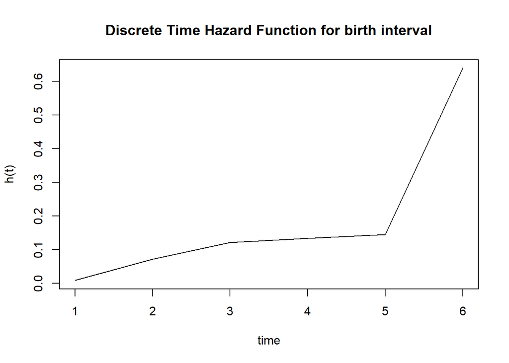

```r
#Plot the hazard function on the probability scale
haz<-1/(1+exp(-coef(fit.0)))
time<-seq(1,6,1)
plot(haz~time, type="l", ylab="h(t)")
title(main="Discrete Time Hazard Function for birth interval")
```

Now we include a single predictor and examine the proportional hazards

```r
fit.1<-svyglm(b2event~as.factor(year)+factor(educ)-1,
              design=des ,
              family=binomial(link="cloglog"))
summary(fit.1)
```

```
Call:
svyglm(formula = b2event ~ as.factor(year) + factor(educ) - 1,
    design = des, family = binomial(link = "cloglog"))

Survey design:
svydesign(ids = ~psu, strata = ~strata, weights = ~weight, data = pp)

Coefficients:
                 Estimate Std. Error t value Pr(>|t|)
as.factor(year)1  -4.4682     0.2140 -20.875  < 2e-16 ***
as.factor(year)2  -2.3290     0.1450 -16.067  < 2e-16 ***
as.factor(year)3  -1.7853     0.1458 -12.245  < 2e-16 ***
as.factor(year)4  -1.6765     0.1313 -12.773  < 2e-16 ***
as.factor(year)5  -1.5854     0.1330 -11.921  < 2e-16 ***
as.factor(year)6   0.2992     0.1278   2.341  0.01951 *
factor(educ)1      0.0917     0.1229   0.746  0.45579
factor(educ)2     -0.3081     0.1305  -2.362  0.01848 *
factor(educ)3     -0.4352     0.1424  -3.056  0.00233 **
---
Signif. codes:  0 '***' 0.001 '**' 0.01 '*' 0.05 '.' 0.1 ' ' 1

(Dispersion parameter for binomial family taken to be 0.9973263)

Number of Fisher Scoring iterations: 7
```

Which shows a lower risk of having a child for highly educated mothers. In fact, it’s a -35.29% lower risk

Next, I do the plots of the hazard functions the Singer and Willett way. I got this code from Singer and Willett’s [example from Ch 11](https://stats.oarc.ucla.edu/r/examples/alda/r-applied-longitudinal-data-analysis-ch-11/)

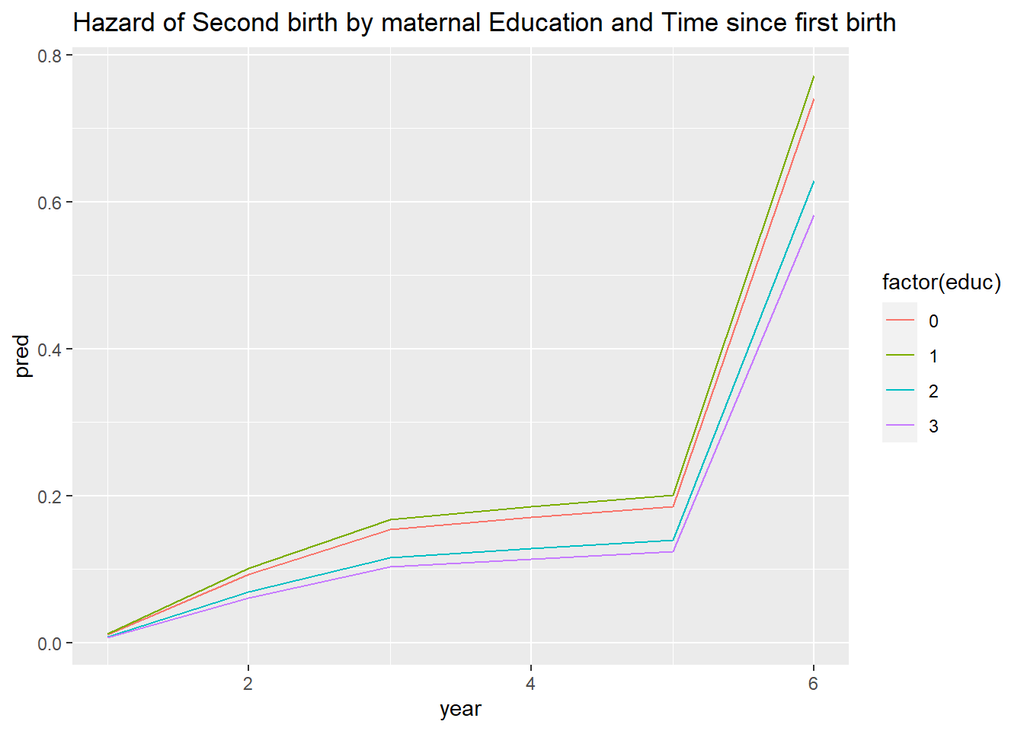

```r
dat4<-expand.grid(year=1:6, educ=c(0,1,2,3))
dat4$pred<-as.numeric(predict(fit.1, newdata=dat4, type="response"))

dat4%>%
  ggplot(aes(x=year, y=pred,color=factor(educ), group=factor(educ) ))+
  geom_line()+
  ggtitle(label="Hazard of Second birth by maternal Education and Time since first birth")
```

See, same thing.